# Individual Model Fits (Corrected Pilot Data) (Excluding RQ objects)

# Averages across all subjects

## NQs & FQ (Model A)

- Target proportion: mean:0.2933 sem: 0.040153
- Target distribution SD: mean:36.9793 sem: 4.6035
- Mean shift: mean:-0.63693 sem: 3.6994
- Rich quadrant proportion: mean:0.31034 sem: 0.041258
- Far quadrant proportion: mean:0.11586 sem: 0.026163
- Biased guessing proportion (same SD used for RQ and FQ proportions): mean:48.3235 sem: 5.2905
- Random guessing proportion: mean:0.28049 sem: 0.044812

## NQs & FQ (Model B)

- Target proportion: mean:0.3073 sem: 0.046812
- Target distribution SD: mean:35.636 sem: 4.4218
- Mean shift: mean:0.21657 sem: 3.6392
- Rich quadrant proportion: mean:0.29987 sem: 0.043965
- Far quadrant proportion: mean:0.10046 sem: 0.021799
- RQ SD: mean:32.158 sem: 4.6563
- FQ SD: mean:46.2543 sem: 5.1092
- Random guessing proportion: mean:0.29237 sem: 0.055946

## NQs only (Model A)

- Target proportion: mean:0.26249 sem: 0.045391
- Target distribution SD: mean:23.5337 sem: 4.2016
- Mean shift: mean:-3.3153 sem: 2.8716
- Rich quadrant proportion: mean:0.35533 sem: 0.049227
- Far quadrant proportion: mean:0.12473 sem: 0.021704
- Biased guessing proportion (same SD used for RQ and FQ proportions): mean:51.2557 sem: 5.1711
- Random guessing proportion: mean:0.25745 sem: 0.04585

## NQs only (Model B)

- Target proportion: mean:0.289 sem: 0.047756
- Target distribution SD: mean:29.6317 sem: 4.6109
- Mean shift: mean:0.29794 sem: 3.4826
- Rich quadrant proportion: mean:0.32928 sem: 0.045289
- Far quadrant proportion: mean:0.12462 sem: 0.024135
- RQ SD: mean:51.9768 sem: 4.851
- FQ SD: mean:48.8681 sem: 5.6223
- Random guessing proportion: mean:0.2571 sem: 0.041363

**Model A: Comparing between NQs/FQ and NQs_only, only sig difference is with targetSD.** **Model B: Comparing between NQs/FQ and NQs_only, sig differences for biasedSD** **NQs/FQ: Comparing between Model A and Model B, no sig differences** **NQs only: Comparing between Model A and Model B, no sig differences**

## Priors (MODEL A): (did test variations on this, which didn't change too much)

[figure not shown]

## Priors (MODEL B):

[figure not shown]

## Exclusions

(also tried toying around with these exclusions, but I had even more trouble than last time when separating the data into our subjective interpretations for who should go where, so I stayed with the same exclusions from before aside from reducing the exclusion for tprop from .15 to .10, as several more subjects had decreased tprop in this corrected data)

#### Target proportion is less than .10

- NQs & FQ (Model A): 6 pilot subjects excluded
- NQs & FQ (Model B): 8 pilot subjects excluded
- NQs only (Model A): 10 pilot subjects excluded
- NQs only (Model B): 9 pilot subjects excluded

#### Average standard deviation across target and biased guessing distributions (weighted by respective proportion fits) exceeds 70 degrees.

```
targetRQFQ = targetfit + RQfit + FQfit;

if targetfit < .10 || ((targetfit * targetSD) + (RQfit * biasedSD) + (FQfit * biasedSD) / targetRQFQ > 70
```

- NQs & FQ (Model A): 3 more pilot subjects excluded
- NQs & FQ (Model B): 1 more pilot subjects excluded
- NQs only (Model A): 3 more pilot subjects excluded
- NQs only (Model B): 1 more pilot subjects excluded

# Collapsed Subjects (all)

## NQs & FQ, Model A

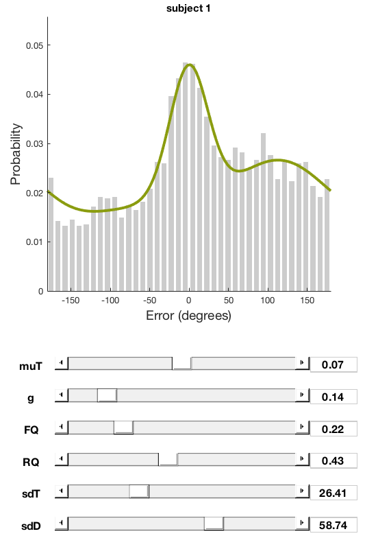

```matlab
cd '/Users/scotti.5/Dropbox/Shared Lab Folder/Experiments/Contextual_LTM/Contextual bias in LTM Exp_V9'
openfig('Model2_noRQ_SUBJCOLLAPSED1.fig');
```

## NQ only, Model A

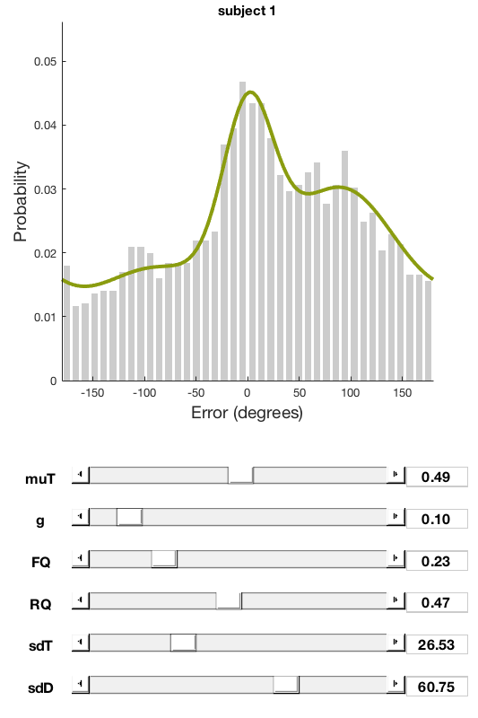

```matlab
cd '/Users/scotti.5/Dropbox/Shared Lab Folder/Experiments/Contextual_LTM/Contextual bias in LTM Exp_V9'
openfig('Model2_NQs_SUBJCOLLAPSED1.fig');
```

## NQs & FQ, Model B

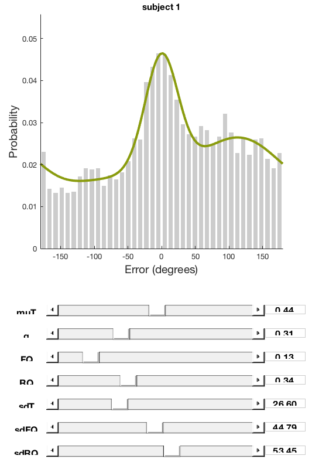

```matlab
cd '/Users/scotti.5/Dropbox/Shared Lab Folder/Experiments/Contextual_LTM/Contextual bias in LTM Exp_V9'
openfig('Model5_noRQ_SUBJCOLLAPSED1.fig');
```

## NQ only, Model B

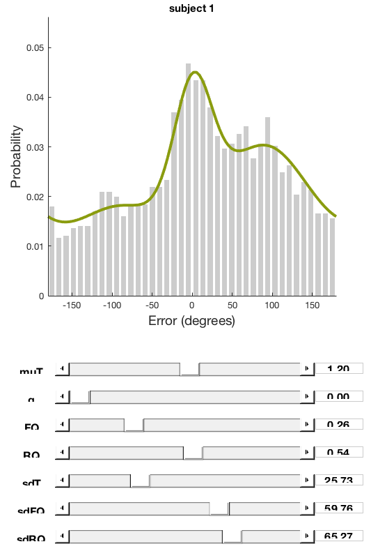

```matlab
cd '/Users/scotti.5/Dropbox/Shared Lab Folder/Experiments/Contextual_LTM/Contextual bias in LTM Exp_V9'
openfig('Model5_NQs_SUBJCOLLAPSED1.fig');
```

# Included subjects only (n=17)

## NQs & FQ, Model A

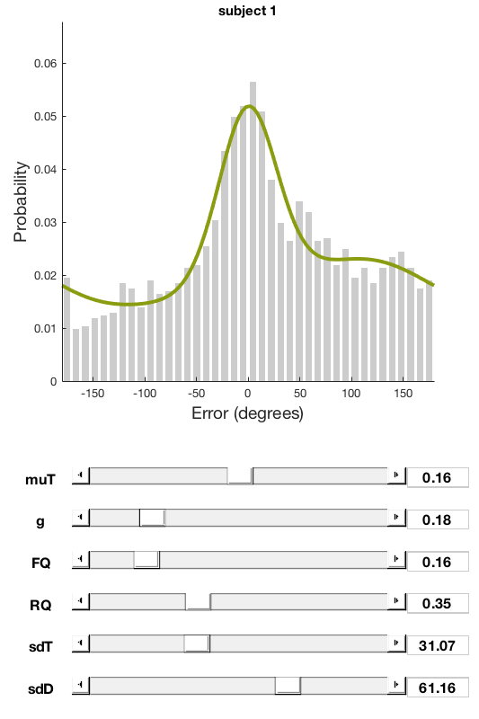

```matlab
cd '/Users/scotti.5/Dropbox/Shared Lab Folder/Experiments/Contextual_LTM/Contextual bias in LTM Exp_V9'
openfig('Model2_noRQ_IncSubjCollapsed1.fig');
```

## Included Subjects (n=17)

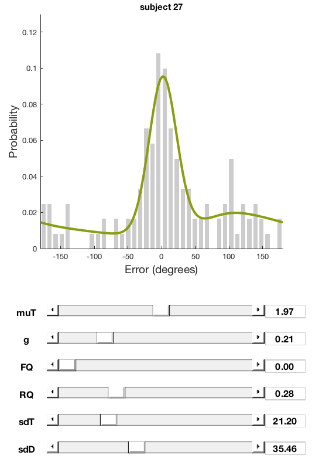

[figure not shown]

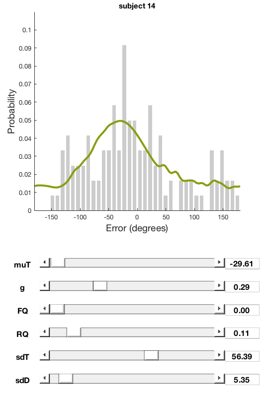

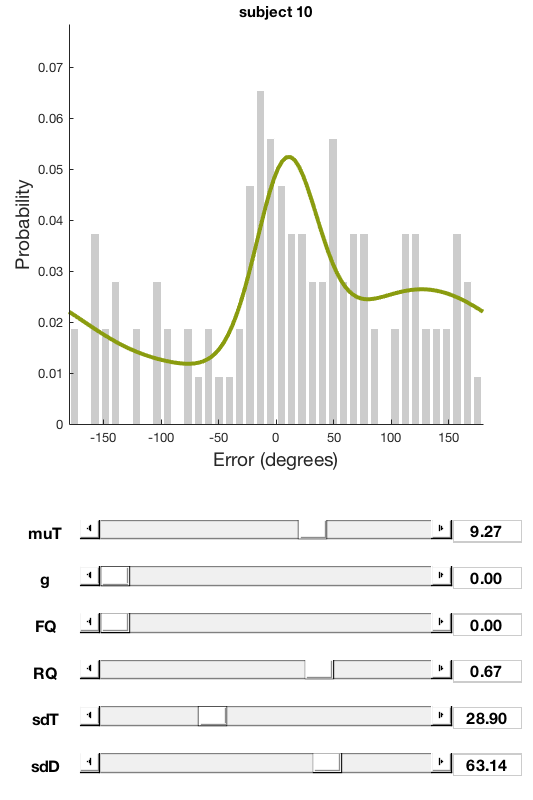

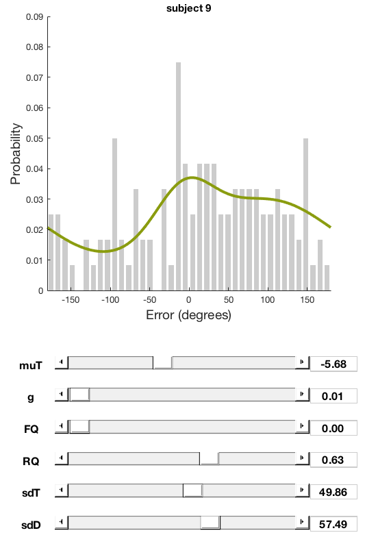

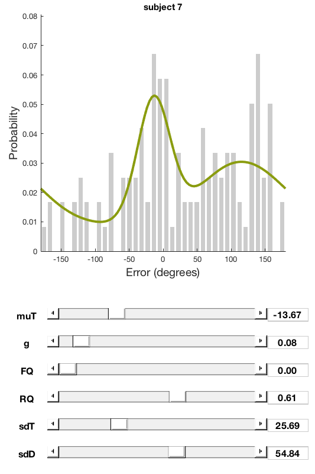

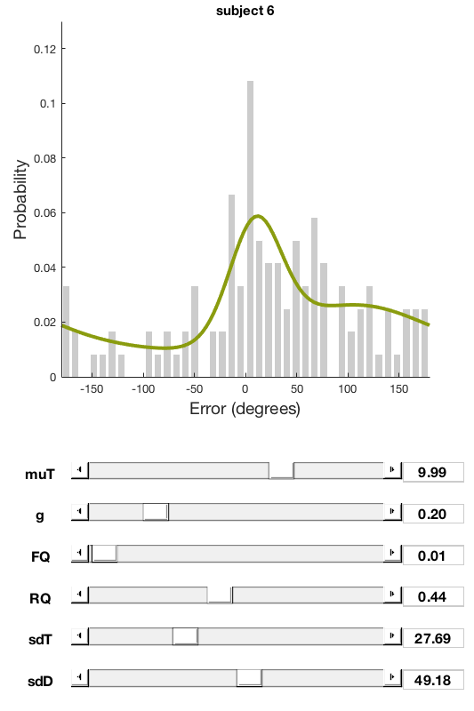

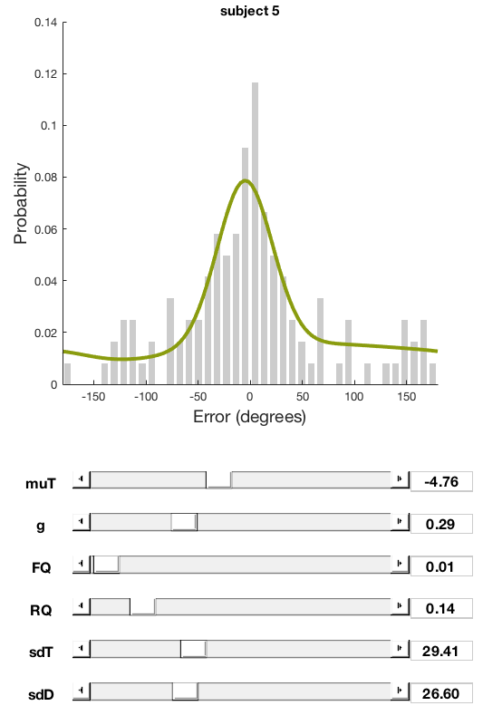

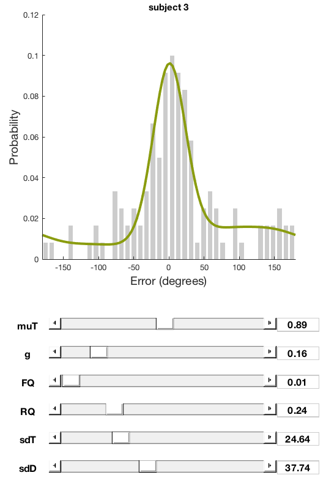

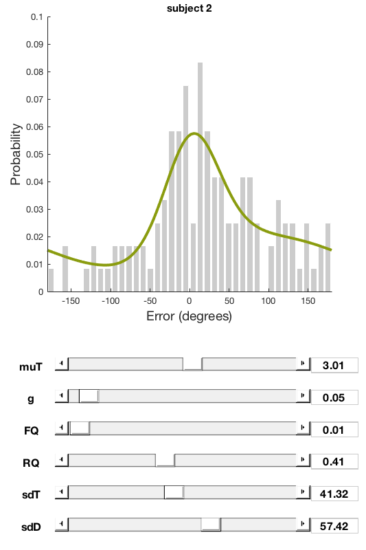

[figure not shown]

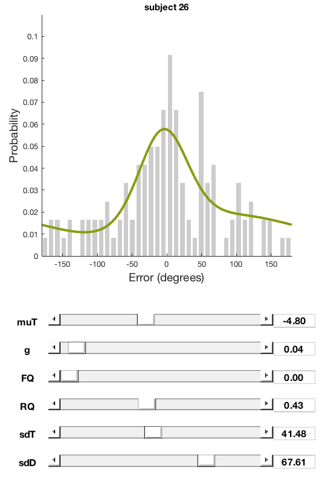

[7 more figures not shown]

```matlab
cd '/Users/scotti.5/Dropbox/Shared Lab Folder/Experiments/Contextual_LTM/Contextual bias in LTM Exp_V9'
openfig('Model2_noRQ_subject2.fig');
openfig('Model2_noRQ_subject3.fig');
openfig('Model2_noRQ_subject5.fig');
openfig('Model2_noRQ_subject6.fig');
openfig('Model2_noRQ_subject7.fig');
openfig('Model2_noRQ_subject8.fig');
openfig('Model2_noRQ_subject9.fig');
openfig('Model2_noRQ_subject10.fig');
openfig('Model2_noRQ_subject14.fig');
openfig('Model2_noRQ_subject15.fig');
openfig('Model2_noRQ_subject17.fig');
openfig('Model2_noRQ_subject18.fig');
openfig('Model2_noRQ_subject19.fig');
openfig('Model2_noRQ_subject20.fig');
openfig('Model2_noRQ_subject22.fig');
openfig('Model2_noRQ_subject22.fig');
openfig('Model2_noRQ_subject26.fig');
openfig('Model2_noRQ_subject27.fig');
```

## Excluded Subjects (n=9)

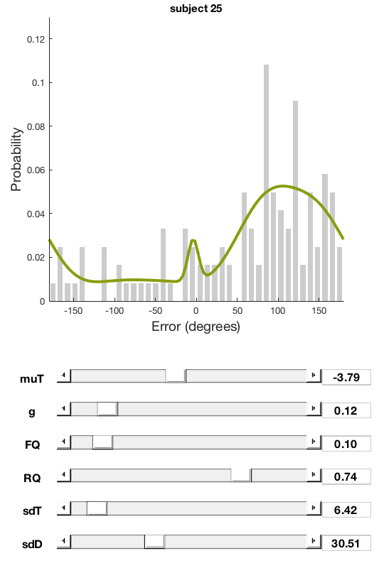

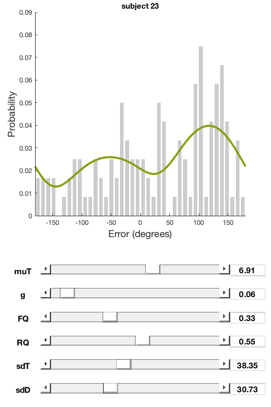

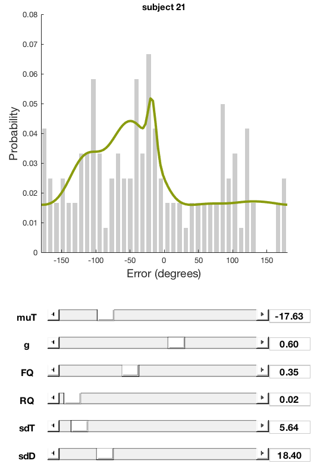

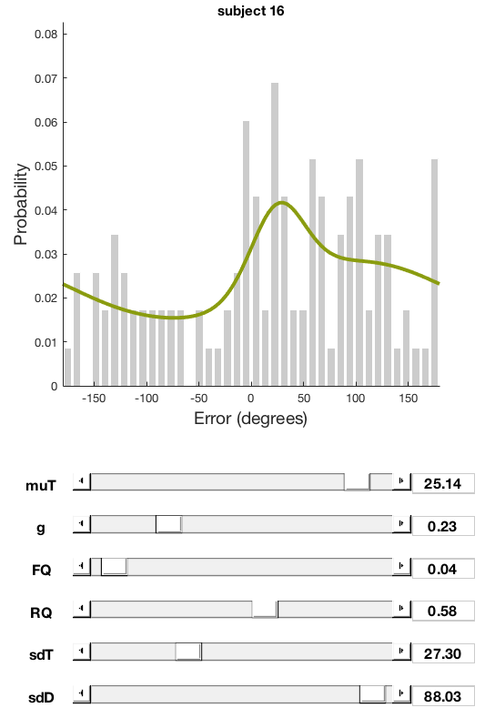

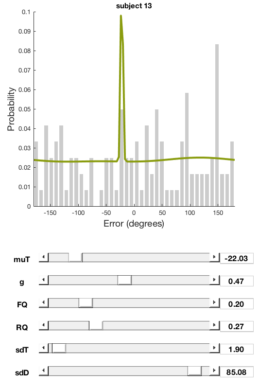

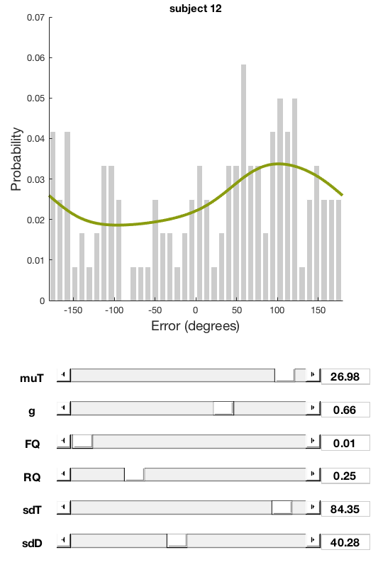

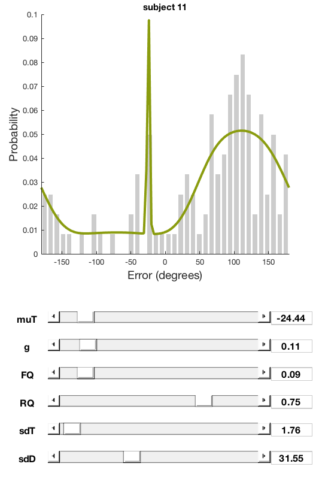

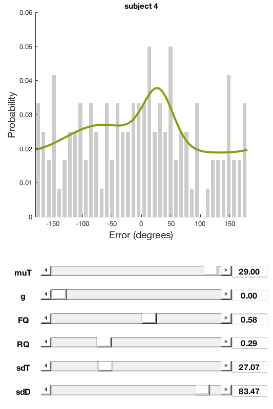

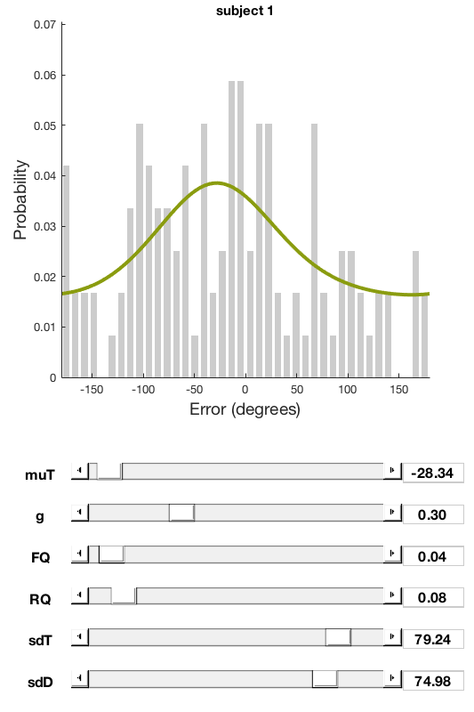

```matlab
cd '/Users/scotti.5/Dropbox/Shared Lab Folder/Experiments/Contextual_LTM/Contextual bias in LTM Exp_V9'
openfig('Model2_noRQ_subject1.fig');
openfig('Model2_noRQ_subject4.fig');
openfig('Model2_noRQ_subject11.fig');
openfig('Model2_noRQ_subject12.fig');
openfig('Model2_noRQ_subject13.fig');
openfig('Model2_noRQ_subject16.fig');
openfig('Model2_noRQ_subject21.fig');
openfig('Model2_noRQ_subject23.fig');
openfig('Model2_noRQ_subject25.fig');
```

# Included Subjects Averages

- Target proportion: mean:0.38393 sem: 0.04075
- Target distribution SD: mean:41.992 sem: 4.0932
- Mean shift: mean:-0.58088 sem: 4.0402
- Rich quadrant proportion: mean:0.26007 sem: 0.039441
- Far quadrant proportion: mean:0.07646 sem: 0.015504
- Biased guessing proportion (same SD used for RQ and FQ proportions): mean:46.052 sem: 6.5274
- Random guessing proportion: mean:0.27954 sem: 0.055286